# Resolución ejercicio 12 (TP4)

Al encontrarse la sección de la derecha del circuito en régimen permamente $(t<0)$, el capacitor se comporta como un circuito abierto y el inductor como un corto-circuito. Se observa entonces que la corriente en el inductor es $I_0=\frac{9V}{3k\Omega}=3mA$. Este será el valor de carga del inductor para $t=0$ cuando el interruptor conmute.

[figure not shown]

Graficaremos nuevamente el circuito para $t>0$ (con el interruptor cerrado) para desarrollar con más claridad.

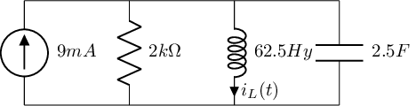

Donde debemos tener en cuenta que la carga inicial en el inductor es $I_0=3mA$

Al ser un circuito de segundo orden debemos calcular $\alpha$ y $\omega_0$

$\alpha=\frac{1}{2RC}=\boxed{100\frac{1}{s}}$ y $\omega_0=\frac{1}{\sqrt{LC}}=\boxed{80\frac{rad}{s}}$

Entonces al ser $\alpha>\omega$ la respuesta del circuito será **sobre-amortiguada** y tendrá la siguiente forma:

$i_L(t)=(A_1 e^{D_1t}+A_2e^{D_2t}+A_3)U(t)$ (1)

donde

$D_{1}=-\alpha+\sqrt{\alpha^2-\omega_0^2}=-40\frac{1}{s}$

$D_{2}=-\alpha-\sqrt{\alpha^2-\omega_0^2}=-160\frac{1}{s}$

El término $A_3$ describe la respuesta forzada por la fuente de corriente continua e indica el valor que tomará la corriente en el inductor para $t=\infty$. Por inspección del circuito, la corriente en el inductor para $t=\infty$ será $i_L(\infty)=9mA= A_3$ ya que el inductor se comportará como un cortocircuito y los $9mA$ de la fuente de corriente circularán por el inductor

Plantearemos entonces el circuito para $t=0$

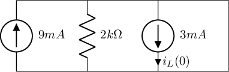

La corriente en el inductor es $3mA$ por lo que la ecuación (1) queda $i_L(0)=A_1 +A_2+9mA=3mA$ o reagrupando

$i_L(0)=A_1 +A_2=-6mA$ (2)

Necesitamos una segunda ecuación para poder calcular $A_1$ y $A_2$. Esta se obtiene a partir de la derivada de (1) y del análisis del circuito para $t=0$.

Ahora debemos igualar esta ecuación a algo que surja del circuito en $t=0$. Como la tensión en el inductor es $v_L(t)=L \frac{di_L(t)}{dt}$ podemos escribir $\frac{di_L(t)}{dt}=\frac{v_L(0)}{L}$. La tensión en el inductor para $t=0$ es $v_L(0)=0V$ ya que está en paralelo con el corto-circuito que representa el capacitor en $t=0$.